# chapter5

2023-11-30

# Chapter 5

## Question 1

Move the country names to rownames (see Exercise 5.5). Show a graphical overview of the data and show summaries of the variables in the data. Describe and interpret the outputs, commenting on the distributions of the variables and the relationships between them. (0-3 points)

```r
library(tibble)
library(readr)
library(corrplot)
library(ggplot2)
library(tidyr)
library(GGally)
human_new <- read_csv("/Users/margot/Desktop/Desktop - MacBook Pro de MARGOT/Open data with R 2023/IODS-project/human_new.csv", show_col_types = FALSE)

str(human_new)
```

```
## spc_tbl_ [155 × 19] (S3: spec_tbl_df/tbl_df/tbl/data.frame)
##  $ HDI.Rank      : num [1:155] 1 2 3 4 5 6 6 8 9 9 ...
##  $ Country       : chr [1:155] "Norway" "Australia" "Switzerland" "Denmark" ...
##  $ HDI           : num [1:155] 0.944 0.935 0.93 0.923 0.922 0.916 0.916 0.915 0.913 0.913 ...
##  $ Life.Exp      : num [1:155] 81.6 82.4 83 80.2 81.6 80.9 80.9 79.1 82 81.8 ...
##  $ Edu.Exp       : num [1:155] 17.5 20.2 15.8 18.7 17.9 16.5 18.6 16.5 15.9 19.2 ...
##  $ Edu.Mean      : num [1:155] 12.6 13 12.8 12.7 11.9 13.1 12.2 12.9 13 12.5 ...
##  $ GNI           : num [1:155] 64992 42261 56431 44025 45435 ...
##  $ GNI.Minus.Rank: num [1:155] 5 17 6 11 9 11 16 3 11 23 ...
##  $ GII.Rank      : num [1:155] 1 2 3 4 5 6 6 8 9 9 ...
##  $ GII           : num [1:155] 0.067 0.11 0.028 0.048 0.062 0.041 0.113 0.28 0.129 0.157 ...
##  $ Mat.Mor       : num [1:155] 4 6 6 5 6 7 9 28 11 8 ...
##  $ Ado.Birth     : num [1:155] 7.8 12.1 1.9 5.1 6.2 3.8 8.2 31 14.5 25.3 ...
##  $ Parli.F       : num [1:155] 39.6 30.5 28.5 38 36.9 36.9 19.9 19.4 28.2 31.4 ...
##  $ Edu2.F        : num [1:155] 97.4 94.3 95 95.5 87.7 96.3 80.5 95.1 100 95 ...
##  $ Edu2.M        : num [1:155] 96.7 94.6 96.6 96.6 90.5 97 78.6 94.8 100 95.3 ...
##  $ Labo.F        : num [1:155] 61.2 58.8 61.8 58.7 58.5 53.6 53.1 56.3 61.6 62 ...
##  $ Labo.M        : num [1:155] 68.7 71.8 74.9 66.4 70.6 66.4 68.1 68.9 71 73.8 ...
##  $ Edu2.FM       : num [1:155] 1.007 0.997 0.983 0.989 0.969 ...
##  $ Labo.FM       : num [1:155] 0.891 0.819 0.825 0.884 0.829 ...
##  - attr(*, "spec")=
##   .. cols(
##   ..   HDI.Rank = col_double(),
##   ..   Country = col_character(),
##   ..   HDI = col_double(),
##   ..   Life.Exp = col_double(),
##   ..   Edu.Exp = col_double(),
##   ..   Edu.Mean = col_double(),
##   ..   GNI = col_double(),
##   ..   GNI.Minus.Rank = col_double(),
##   ..   GII.Rank = col_double(),
##   ..   GII = col_double(),
##   ..   Mat.Mor = col_double(),
##   ..   Ado.Birth = col_double(),
##   ..   Parli.F = col_double(),
##   ..   Edu2.F = col_double(),
##   ..   Edu2.M = col_double(),
##   ..   Labo.F = col_double(),
##   ..   Labo.M = col_double(),
##   ..   Edu2.FM = col_double(),
##   ..   Labo.FM = col_double()
##   .. )
##  - attr(*, "problems")=<externalptr>
```

```r
# Country is as rownames
human_new <- column_to_rownames(human_new, "Country")

is.na(human_new)
```

[output not shown]

[output cut: 725 more lines]

[output not shown]

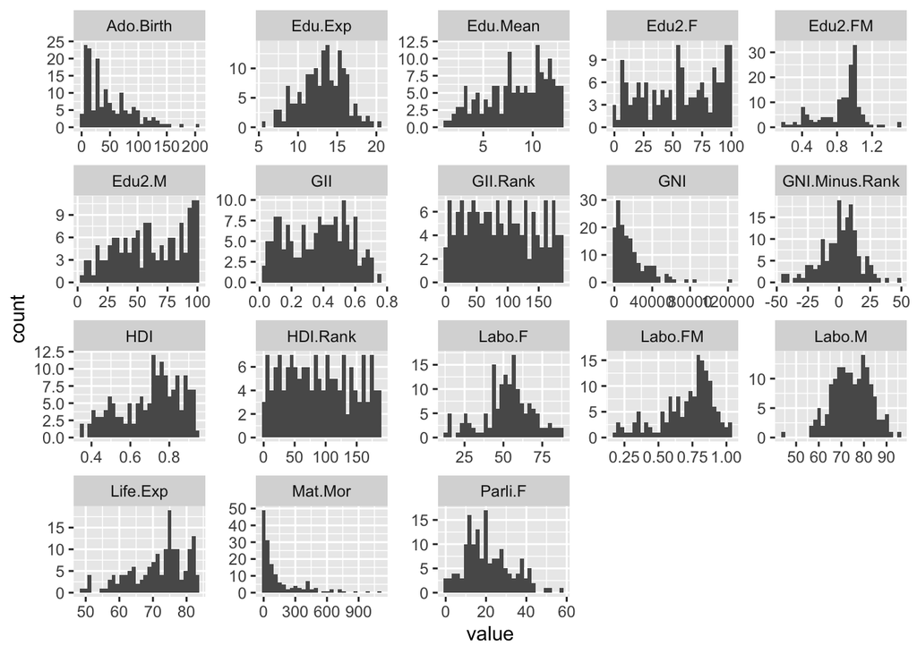

```r
# histogram per variable
pivot_longer(human_new, cols = everything()) %>%
  ggplot(aes(value)) + facet_wrap("name", scales = "free") +
  geom_histogram()
```

[figure not shown]

```r
# charts and correlations - data is not very visible
ggpairs(human_new,lower=list(combo=wrap("facethist",binwidth=0.1)))
```

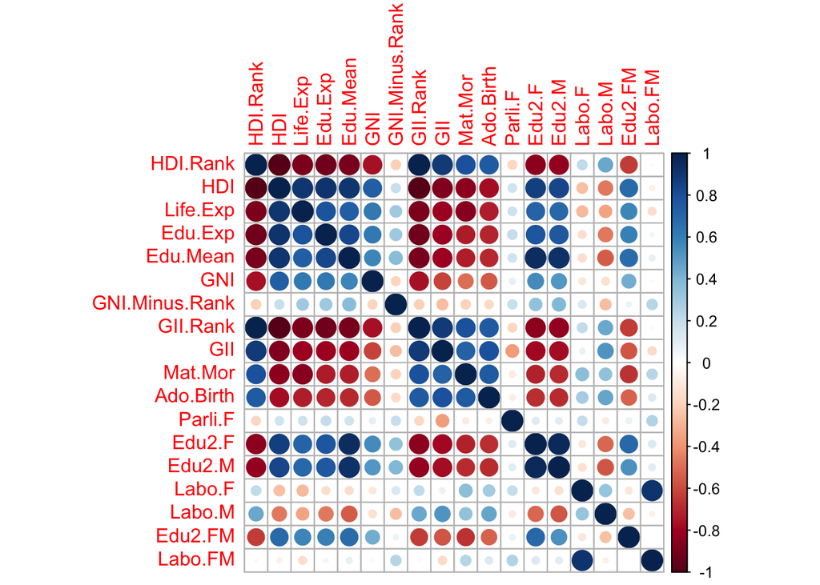

```r
# correlation between variables

c <- cor(human_new)
corrplot(c, method="circle")
```

HDI, Life exp, edu exp, edu mean is negatively correlated with GII, Mat mortality, ado birth HDI, Life exp; edu exp, edu mean is positively correlated with edu 2 of male and female, GII, ado birth and mat mortality are positvely correlated GII and math mortality are negatively correlated with edu for female an male

## Question 2

Perform principal component analysis (PCA) on the raw (non-standardized) human data. Show the variability captured by the principal components. Draw a biplot displaying the observations by the first two principal components (PC1 coordinate in x-axis, PC2 coordinate in y-axis), along with arrows representing the original variables. (0-2 points)

[output not shown]

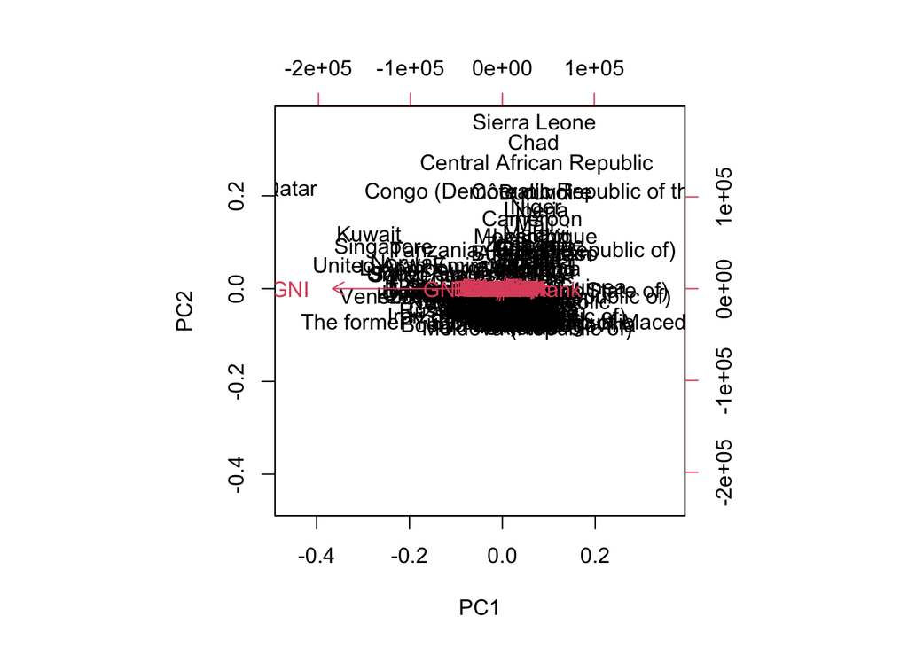

```r
# pca
pca_human <- prcomp(human_new)

# draw a biplot of the principal component representation and the original variables
biplot(pca_human, choices = 1:2)
```

## Question 3

Standardize the variables in the human data and repeat the above analysis. Interpret the results of both analysis (with and without standardizing). Are the results different? Why or why not? Include captions (brief descriptions) in your plots where you describe the results by using not just your variable names, but the actual phenomena they relate to. (0-4 points)

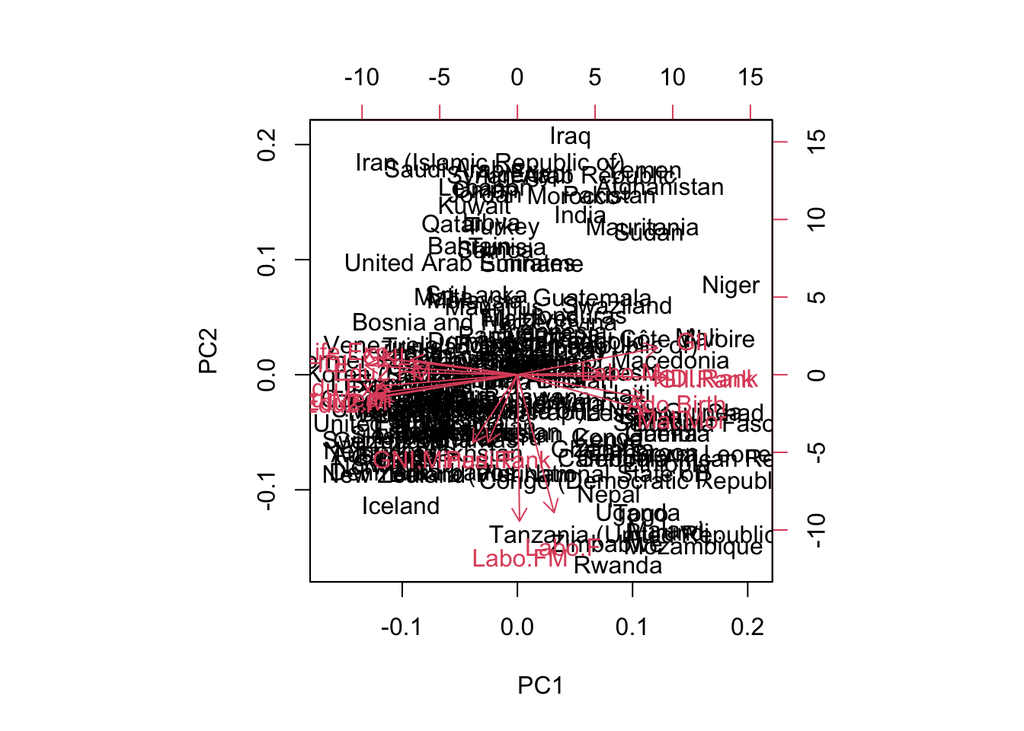

```r
# standardize human_new
scaled_human <- scale(human_new)

# new PCA
pca_human2 <- prcomp(scaled_human)

# draw a biplot of the principal component representation and the original variables with the scaled data
biplot(pca_human2, choices = 1:2)
```

```r
# Question: How to make it readable? what is expected in this question?

# Interpret the results of both analysis (with and without standardizing). Are the results different? Why or why not? Include captions (brief descriptions) in your plots where you describe the results by using not just your variable names, but the actual phenomena they relate to.
# yes because each variable have different weight in the model, that is why it is necessary to scale / standardize the data

# Let's reduce the dataset with only the last 30 countries and few of the variables.
scaled_human2 <- scaled_human %>% tail(n=30)
scaled_human2 <- as.data.frame(scaled_human2)
scaled_human2 %>% dplyr::select(HDI,GNI,GII,Edu.Exp,Life.Exp,Mat.Mor,Ado.Birth,Edu2.F,Edu2.M)
```

```
##                                          HDI        GNI       GII    Edu.Exp
## Swaziland                          -1.116487 -0.6517472 0.9982202 -0.6605505
## Tanzania (United Republic of)      -1.181055 -0.8205902 0.9459891 -1.3999219
## Cameroon                           -1.239166 -0.7994511 1.1549134 -0.9774240
## Zimbabwe                           -1.258537 -0.8635155 0.7213955 -0.8013832
## Mauritania                         -1.277907 -0.7586289 1.2750449 -1.6463790
## Papua New Guinea                   -1.284364 -0.8177860 1.2802680 -1.1534648
## Yemen                              -1.329562 -0.7608399 1.9749414 -1.3999219
## Lesotho                            -1.336019 -0.7723262 0.9146505 -0.7309668
## Togo                               -1.419957 -0.8843849 1.1601365 -0.3436771
## Haiti                              -1.426414 -0.8606034 1.2384832 -1.5759627
## Rwanda                             -1.426414 -0.8719819 0.1781922 -1.0126321
## Uganda                             -1.426414 -0.8636233 0.8989811 -1.1886729
## Benin                              -1.445784 -0.8553187 1.2959373 -0.7309668
## Sudan                              -1.452241 -0.7452013 1.1758059 -2.1745014
## Senegal                            -1.536180 -0.8326157 0.8467501 -1.8576279
## Afghanistan                        -1.542637 -0.8489554 1.7085629 -1.3647137
## Côte d'Ivoire                      -1.562007 -0.7796062 1.6354394 -1.5055464
## Malawi                             -1.671773 -0.9103234 1.2802680 -0.8365913
## Ethiopia                           -1.691143 -0.8735997 1.0034433 -1.6463790
## Gambia                             -1.697600 -0.8693395 1.3377222 -1.5407545
## Congo (Democratic Republic of the) -1.749255 -0.9139365 1.6041007 -1.1886729
## Liberia                            -1.768625 -0.9071957 1.4891923 -1.2942974
## Mali                               -1.839650 -0.8652411 1.6249931 -1.6815871
## Mozambique                         -1.859020 -0.8900472 1.1758059 -1.3647137
## Sierra Leone                       -1.878391 -0.8546176 1.4839692 -1.6111708
## Burkina Faso                       -1.949416 -0.8648097 1.3847302 -1.8928361
## Burundi                            -1.962329 -0.9097302 0.6587182 -1.0830484
## Chad                               -2.013984 -0.8381701 1.7764633 -2.0336687
## Central African Republic           -2.285170 -0.9192752 1.5100848 -2.1040851
## Niger                              -2.298084 -0.9016413 1.8130250 -2.7378319
##                                      Life.Exp   Mat.Mor    Ado.Birth     Edu2.F
## Swaziland                          -2.7188401 0.7597924  0.604233786 -1.0822449
## Tanzania (United Republic of)      -0.7985475 1.2319592  1.837448830 -1.6092561
## Cameroon                           -1.9387212 2.0818593  1.669614830 -1.1016441
## Zimbabwe                           -1.6986846 1.5152592  0.319645699 -0.2157481
## Mauritania                         -1.0265822 0.8070091  0.635854684 -1.5219597
## Papua New Guinea                   -1.0865914 0.3348424  0.363428481 -1.5445921
## Yemen                              -0.9425694 0.5709257 -0.003860417 -1.5122601
## Lesotho                            -2.6228255 1.6096926  1.027467351 -1.0822449
```

[output cut: 38 more lines]

```
## Afghanistan                        -1.09720513
## Côte d'Ivoire                      -1.08654531
## Malawi                             -1.38857359
## Ethiopia                           -1.50938490
## Gambia                             -1.03679948
## Congo (Democratic Republic of the) -1.00482001
## Liberia                            -0.75964411
## Mali                               -1.61953640
## Mozambique                         -1.93577777
## Sierra Leone                       -1.38502032
## Burkina Faso                       -2.04237599
## Burundi                            -1.86115902
## Chad                               -1.80430664
## Central African Republic           -1.20735662
## Niger                              -1.87892539
```

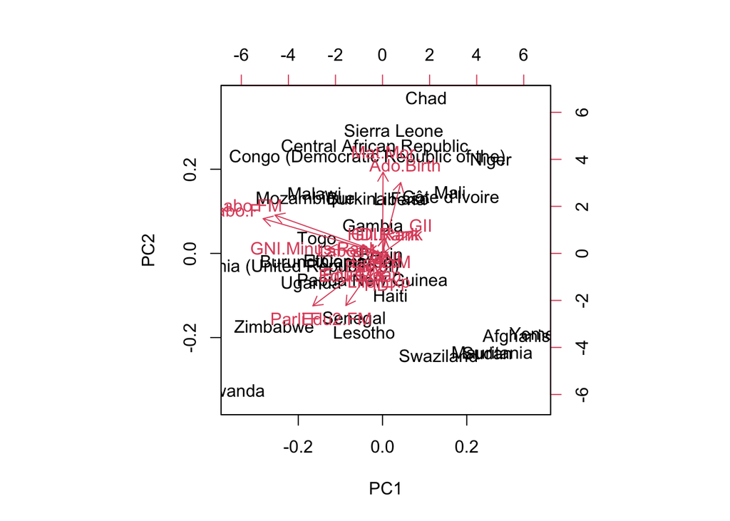

```r
pca_human3 <- prcomp(scaled_human2)
biplot(pca_human3, choices = 1:2)
```

## Question 4

Give your personal interpretations of the first two principal component dimensions based on the biplot drawn after PCA on the standardized human data. (0-2 points)

```r
# Question: How to analyze when we cannot read it well?
```

## Question 5

The tea data comes from the FactoMineR package and it is measured with a questionnaire on tea: 300 individuals were asked how they drink tea (18 questions) and what are their product’s perception (12 questions). In addition, some personal details were asked (4 questions).

Load the tea dataset and convert its character variables to factors:

tea <- read.csv(“https://raw.githubusercontent.com/KimmoVehkalahti/Helsinki-Open-Data-Science/master/datasets/tea.csv”, stringsAsFactors = TRUE) Explore the data briefly: look at the structure and the dimensions of the data. Use View(tea) to browse its contents, and visualize the data.

Use Multiple Correspondence Analysis (MCA) on the tea data (or on just certain columns of the data, it is up to you!). Interpret the results of the MCA and draw at least the variable biplot of the analysis. You can also explore other plotting options for MCA. Comment on the output of the plots. (0-4 points)

```r
tea_new <- read.csv("https://raw.githubusercontent.com/KimmoVehkalahti/Helsinki-Open-Data-Science/master/datasets/tea.csv", stringsAsFactors = TRUE)
view(tea_new)
str(tea_new)
```

```
## 'data.frame':    300 obs. of  36 variables:
##  $ breakfast       : Factor w/ 2 levels "breakfast","Not.breakfast": 1 1 2 2 1 2 1 2 1 1 ...
##  $ tea.time        : Factor w/ 2 levels "Not.tea time",..: 1 1 2 1 1 1 2 2 2 1 ...
##  $ evening         : Factor w/ 2 levels "evening","Not.evening": 2 2 1 2 1 2 2 1 2 1 ...
##  $ lunch           : Factor w/ 2 levels "lunch","Not.lunch": 2 2 2 2 2 2 2 2 2 2 ...
##  $ dinner          : Factor w/ 2 levels "dinner","Not.dinner": 2 2 1 1 2 1 2 2 2 2 ...
##  $ always          : Factor w/ 2 levels "always","Not.always": 2 2 2 2 1 2 2 2 2 2 ...
##  $ home            : Factor w/ 2 levels "home","Not.home": 1 1 1 1 1 1 1 1 1 1 ...
##  $ work            : Factor w/ 2 levels "Not.work","work": 1 1 2 1 1 1 1 1 1 1 ...
##  $ tearoom         : Factor w/ 2 levels "Not.tearoom",..: 1 1 1 1 1 1 1 1 1 2 ...
##  $ friends         : Factor w/ 2 levels "friends","Not.friends": 2 2 1 2 2 2 1 2 2 2 ...
##  $ resto           : Factor w/ 2 levels "Not.resto","resto": 1 1 2 1 1 1 1 1 1 1 ...
##  $ pub             : Factor w/ 2 levels "Not.pub","pub": 1 1 1 1 1 1 1 1 1 1 ...
##  $ Tea             : Factor w/ 3 levels "black","Earl Grey",..: 1 1 2 2 2 2 2 1 2 1 ...
##  $ How             : Factor w/ 4 levels "alone","lemon",..: 1 3 1 1 1 1 1 3 3 1 ...
```

[output cut: 22 more lines]

[figure not shown]

```r
# variables are factorial, except few ones. let's map the different values with MCA

# But first let's keep only the categorical variables. We could also change the variables to categorical ones.
tea_new_2 <- tea_new %>% dplyr::select(-breakfast,-age)

library(ggplot2)
pivot_longer(tea_new_2, cols = everything()) %>%
  ggplot(aes(value)) + facet_wrap("name", scales = "free") +
  geom_bar() +
  theme(axis.text.x = element_text(angle = 45, hjust = 1, size = 8))
```

```r
# too many variables, it is hard to see.
# Question: how to select the variables we want to use? should they have less correlation?


library(FactoMineR)
mca <- MCA(tea_new_2, graph = FALSE)

# summary of the model
summary(mca)
```

```
##
## Call:
## MCA(X = tea_new_2, graph = FALSE)
##
##
## Eigenvalues
##                        Dim.1   Dim.2   Dim.3   Dim.4   Dim.5   Dim.6   Dim.7
## Variance               0.092   0.084   0.072   0.060   0.057   0.055   0.050
## % of var.              5.913   5.392   4.629   3.881   3.672   3.502   3.188
## Cumulative % of var.   5.913  11.305  15.934  19.815  23.488  26.989  30.177
##                        Dim.8   Dim.9  Dim.10  Dim.11  Dim.12  Dim.13  Dim.14
## Variance               0.049   0.048   0.045   0.042   0.042   0.039   0.038
## % of var.              3.138   3.050   2.885   2.675   2.672   2.491   2.424
## Cumulative % of var.  33.315  36.365  39.251  41.926  44.598  47.089  49.513
##                       Dim.15  Dim.16  Dim.17  Dim.18  Dim.19  Dim.20  Dim.21
## Variance               0.036   0.036   0.034   0.032   0.032   0.031   0.030
## % of var.              2.320   2.305   2.173   2.077   2.049   2.016   1.944
## Cumulative % of var.  51.833  54.138  56.311  58.387  60.436  62.453  64.397
##                       Dim.22  Dim.23  Dim.24  Dim.25  Dim.26  Dim.27  Dim.28
## Variance               0.029   0.027   0.026   0.026   0.025   0.024   0.024
## % of var.              1.880   1.761   1.692   1.669   1.624   1.553   1.544
## Cumulative % of var.  66.276  68.038  69.730  71.399  73.023  74.577  76.120
##                       Dim.29  Dim.30  Dim.31  Dim.32  Dim.33  Dim.34  Dim.35
## Variance               0.023   0.022   0.022   0.021   0.020   0.019   0.019
## % of var.              1.456   1.426   1.404   1.339   1.264   1.246   1.221
## Cumulative % of var.  77.576  79.002  80.406  81.745  83.009  84.255  85.476
##                       Dim.36  Dim.37  Dim.38  Dim.39  Dim.40  Dim.41  Dim.42
## Variance               0.017   0.017   0.017   0.016   0.016   0.015   0.015
## % of var.              1.120   1.112   1.078   1.028   1.005   0.968   0.939
## Cumulative % of var.  86.596  87.708  88.786  89.814  90.819  91.786  92.725
##                       Dim.43  Dim.44  Dim.45  Dim.46  Dim.47  Dim.48  Dim.49
## Variance               0.013   0.013   0.012   0.012   0.011   0.010   0.010
## % of var.              0.866   0.837   0.802   0.739   0.697   0.674   0.666
## Cumulative % of var.  93.590  94.427  95.229  95.968  96.666  97.339  98.005
##                       Dim.50  Dim.51  Dim.52  Dim.53
## Variance               0.009   0.008   0.007   0.006
## % of var.              0.603   0.531   0.458   0.403
## Cumulative % of var.  98.608  99.139  99.597 100.000
##
## Individuals (the 10 first)
```

[output cut: 44 more lines]

```
## always        0.095  0.126  0.005  1.186 |
## Not.always   -0.050  0.066  0.005 -1.186 |
##
## Categorical variables (eta2)
##                Dim.1 Dim.2 Dim.3
## tea.time     | 0.236 0.000 0.003 |
## evening      | 0.046 0.085 0.055 |
## lunch        | 0.060 0.028 0.011 |
## dinner       | 0.082 0.000 0.042 |
## always       | 0.061 0.034 0.005 |
## home         | 0.013 0.002 0.027 |
## work         | 0.071 0.020 0.027 |
## tearoom      | 0.326 0.021 0.027 |
## friends      | 0.201 0.058 0.024 |
## resto        | 0.155 0.007 0.030 |
```

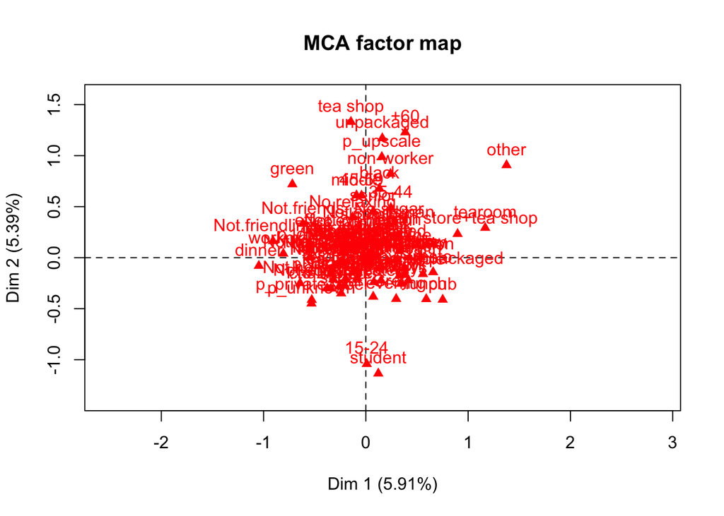

```r
# visualize MCA - visualize many categories from many variables, all at once to see the ones that fit together as the same behavior. e.g unpackages and tea shop will belong to the same type of user.
plot(mca, invisible=c("ind"), graph.type = "classic")
```

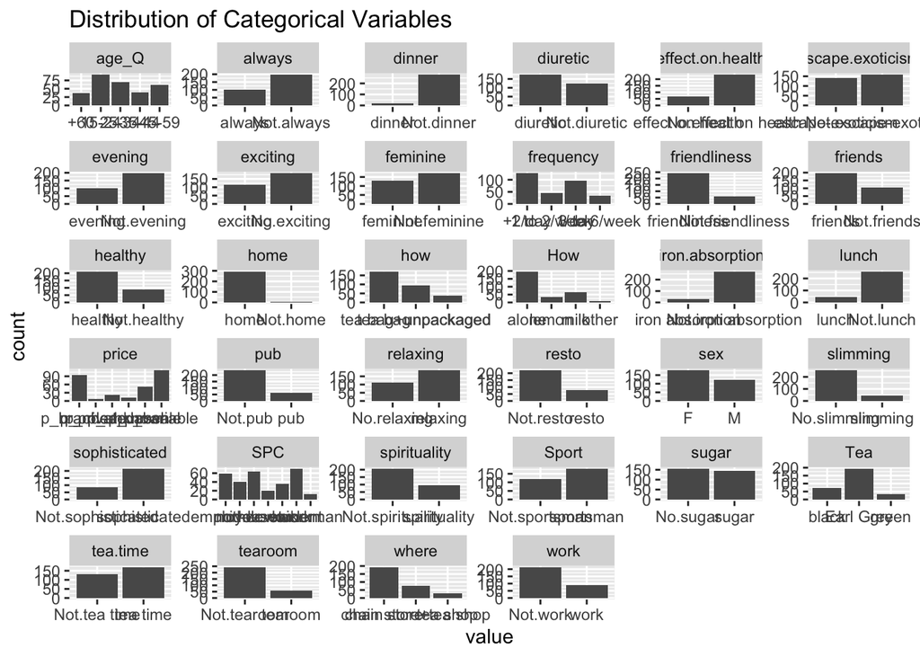

```r
# let's now choose only few variables: SELECT OTHER VARIABLES, QUESTION: ow to analyzes the correlation between only categorical variables to then select the ones i want to study with the mca
tea_new_2 %>%
  pivot_longer(cols = everything()) %>%
  ggplot(aes(x = value)) +
  facet_wrap(~ name, scales = "free") +
  geom_bar() +
  labs(title = "Distribution of Categorical Variables")
```

```r
# Select smaller dataset to do the mca analyze
str(tea_new)
```

```
## 'data.frame':    300 obs. of  36 variables:
##  $ breakfast       : Factor w/ 2 levels "breakfast","Not.breakfast": 1 1 2 2 1 2 1 2 1 1 ...
##  $ tea.time        : Factor w/ 2 levels "Not.tea time",..: 1 1 2 1 1 1 2 2 2 1 ...
##  $ evening         : Factor w/ 2 levels "evening","Not.evening": 2 2 1 2 1 2 2 1 2 1 ...
##  $ lunch           : Factor w/ 2 levels "lunch","Not.lunch": 2 2 2 2 2 2 2 2 2 2 ...
##  $ dinner          : Factor w/ 2 levels "dinner","Not.dinner": 2 2 1 1 2 1 2 2 2 2 ...
##  $ always          : Factor w/ 2 levels "always","Not.always": 2 2 2 2 1 2 2 2 2 2 ...
##  $ home            : Factor w/ 2 levels "home","Not.home": 1 1 1 1 1 1 1 1 1 1 ...
##  $ work            : Factor w/ 2 levels "Not.work","work": 1 1 2 1 1 1 1 1 1 1 ...
##  $ tearoom         : Factor w/ 2 levels "Not.tearoom",..: 1 1 1 1 1 1 1 1 1 2 ...
##  $ friends         : Factor w/ 2 levels "friends","Not.friends": 2 2 1 2 2 2 1 2 2 2 ...
##  $ resto           : Factor w/ 2 levels "Not.resto","resto": 1 1 2 1 1 1 1 1 1 1 ...
##  $ pub             : Factor w/ 2 levels "Not.pub","pub": 1 1 1 1 1 1 1 1 1 1 ...
##  $ Tea             : Factor w/ 3 levels "black","Earl Grey",..: 1 1 2 2 2 2 2 1 2 1 ...
##  $ How             : Factor w/ 4 levels "alone","lemon",..: 1 3 1 1 1 1 1 3 3 1 ...
```

[output cut: 22 more lines]

```r
tea_smaller <- tea_new %>% dplyr::select(exciting,relaxing,effect.on.health,sex,where,sugar)

# model
mca2 <- MCA(tea_smaller, graph = FALSE)

# summary of the model
summary(mca2)
```

```
##
## Call:
## MCA(X = tea_smaller, graph = FALSE)
##
##
## Eigenvalues
##                        Dim.1   Dim.2   Dim.3   Dim.4   Dim.5   Dim.6   Dim.7
## Variance               0.226   0.211   0.183   0.160   0.156   0.123   0.108
## % of var.             19.413  18.045  15.680  13.683  13.381  10.541   9.257
## Cumulative % of var.  19.413  37.458  53.138  66.822  80.202  90.743 100.000
##
## Individuals (the 10 first)
##                         Dim.1    ctr   cos2    Dim.2    ctr   cos2    Dim.3
## 1                    |  0.385  0.219  0.158 | -0.267  0.113  0.076 | -0.087
## 2                    |  0.091  0.012  0.009 |  0.587  0.546  0.363 | -0.549
## 3                    | -0.667  0.655  0.722 | -0.123  0.024  0.024 | -0.007
## 4                    |  0.093  0.013  0.011 | -0.803  1.021  0.840 |  0.058
## 5                    | -0.223  0.073  0.067 | -0.384  0.234  0.198 |  0.212
## 6                    | -0.223  0.073  0.067 | -0.384  0.234  0.198 |  0.212
## 7                    | -0.223  0.073  0.067 | -0.384  0.234  0.198 |  0.212
## 8                    | -0.667  0.655  0.722 | -0.123  0.024  0.024 | -0.007
## 9                    | -0.362  0.193  0.117 | -0.051  0.004  0.002 |  0.264
## 10                   | -0.362  0.193  0.117 | -0.051  0.004  0.002 |  0.264
##                         ctr   cos2
## 1                     0.014  0.008 |
## 2                     0.550  0.317 |
## 3                     0.000  0.000 |
## 4                     0.006  0.004 |
## 5                     0.082  0.060 |
## 6                     0.082  0.060 |
## 7                     0.082  0.060 |
## 8                     0.000  0.000 |
## 9                     0.127  0.062 |
## 10                    0.127  0.062 |
##
## Categories (the 10 first)
##                          Dim.1     ctr    cos2  v.test     Dim.2     ctr
## exciting             |   0.816  18.946   0.420  11.203 |   0.294   2.655
## No.exciting          |  -0.514  11.944   0.420 -11.203 |  -0.186   1.674
## No.relaxing          |   0.521   7.521   0.164   7.002 |   0.919  25.182
```

[output cut: 12 more lines]

```
## effect on health       0.072   4.631 |   0.866  15.046   0.212   7.956 |
## No.effect on health    0.072  -4.631 |  -0.244   4.244   0.212  -7.956 |
## F                      0.125   6.115 |  -0.228   2.821   0.076  -4.772 |
## M                      0.125  -6.115 |   0.333   4.116   0.076   4.772 |
## chain store            0.165  -7.017 |  -0.271   4.276   0.130  -6.243 |
## chain store+tea shop   0.132   6.282 |  -0.139   0.456   0.007  -1.422 |
##
## Categorical variables (eta2)
##                        Dim.1 Dim.2 Dim.3
## exciting             | 0.420 0.055 0.248 |
## relaxing             | 0.164 0.510 0.032 |
## effect.on.health     | 0.076 0.072 0.212 |
## sex                  | 0.389 0.125 0.076 |
## where                | 0.108 0.170 0.490 |
## sugar                | 0.203 0.332 0.039 |
```

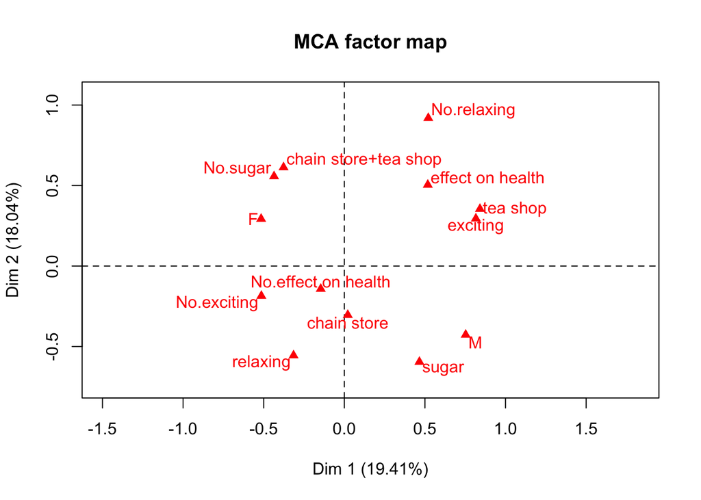

```r
# visualize MCA
plot(mca2, invisible=c("ind"), graph.type = "classic")
```